# **Weight Initialisation**

The optimization landscape of a deep neural network is **non-convex**, **high-dimensional**, and filled with **local minima**, saddle points, and flat regions. The starting point—determined by the **initial weights**—strongly influences the path the optimizer takes through this complex loss surface.

If the weights are initialized poorly, gradients may either **vanish** or **explode**, leading to stalled training or divergence. On the other hand, good initialization brings the model closer to an optimal solution.

## **A Simple Example: Equal Weight Initialization**

Suppose all weights in a network layer are initialized to the same value. This creates a **symmetry problem**—all neurons in the layer produce the same output and receive the same gradient. As a result, they evolve identically during training, defeating the purpose of having multiple neurons.

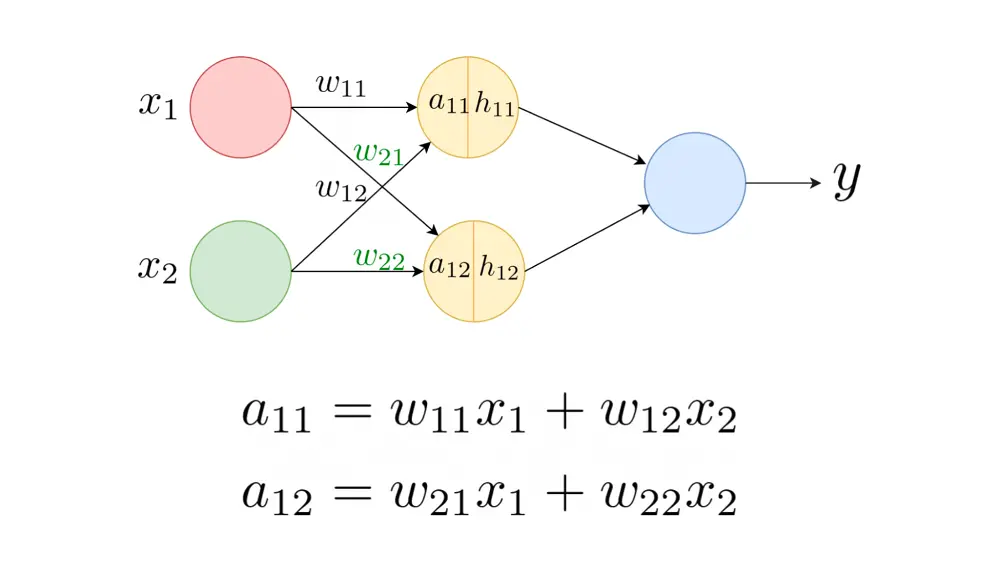

So, we need random initialisation for better learning.

Let's take tanh and sigmoid activation for simplicity.

For small random values of weights, we observe that the activations grow smaller as we go deeper into the neural network.

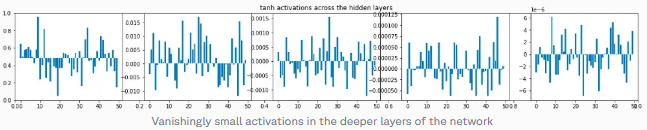

For large random values of weights, the sigmoid and tanh activation functions take on values very close to saturation, as shown below. When the activations become saturated, the gradients move close to zero during backpropagation.

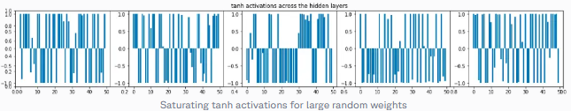

We need randomness in a **controlled** manner.

## **Historical Initialization Techniques**

### **Greedy Layerwise Unsupervised Pre Training**

Before the era of ReLUs and batch norm, one common method was **greedy layerwise pretraining**. Here's how it worked:

For the first hidden layer, an **unsupervised learning algorithm** (like an autoencoder or RBM) is used to learn weights.The output from this layer is passed to the next, where another unsupervised model learns new weights.This process continues layer by layer, initializing the full network.Finally, supervised fine-tuning is done via backpropagation.

While largely outdated, this technique laid the groundwork for modern deep learning.

## **Modern Initialization Schemes**

Armed with the variance analysis from the latest research, modern initialization strategies aim to preserve activation and gradient variance across layers:

**a) Xavier (Glorot) Initialization**

### **b) He Initialization**

ReLU activations are not symmetric and clip negative values, so He initialization increases the variance slightly to compensate for this.

The mathematics behind this can be found in this research paper: [Understanding the difficulty of training deep feedforward neural networks](https://proceedings.mlr.press/v9/glorot10a/glorot10a.pdf)